# Online Retail Analytics

FNU Dimple

2024-10-06

Firstly, load necessary libraries

```r
library(class)
library(caret)
library(tinytex)
library(e1071)
library(readr)
library(dplyr)
library(zoo)
```

# Load the data into R

```r
Online_Retail <- read_csv("~/Downloads/BA Online_Retail-2.csv")
summary(Online_Retail) # Summary
```

```
##   InvoiceNo          StockCode         Description           Quantity
##  Length:541909      Length:541909      Length:541909      Min.   :-80995.00
##  Class :character   Class :character   Class :character   1st Qu.:     1.00
##  Mode  :character   Mode  :character   Mode  :character   Median :     3.00
##                                                           Mean   :     9.55
##                                                           3rd Qu.:    10.00
##                                                           Max.   : 80995.00
##
##  InvoiceDate          UnitPrice           CustomerID       Country
##  Length:541909      Min.   :-11062.06   Min.   :12346    Length:541909
##  Class :character   1st Qu.:     1.25   1st Qu.:13953    Class :character
##  Mode  :character   Median :     2.08   Median :15152    Mode  :character
##                     Mean   :     4.61   Mean   :15288
##                     3rd Qu.:     4.13   3rd Qu.:16791
##                     Max.   : 38970.00   Max.   :18287
##                                         NA's   :135080
```

```r
dim(Online_Retail) # Dimension
```

```
## [1] 541909      8
```

Check the first few rows, last rows and structure of the dataset.

```r
head(Online_Retail)
```

```
## # A tibble: 6 × 8
##   InvoiceNo StockCode Description      Quantity InvoiceDate UnitPrice CustomerID
##   <chr>     <chr>     <chr>               <dbl> <chr>           <dbl>      <dbl>
## 1 536365    85123A    WHITE HANGING H…        6 12/1/2010 …      2.55      17850
## 2 536365    71053     WHITE METAL LAN…        6 12/1/2010 …      3.39      17850
## 3 536365    84406B    CREAM CUPID HEA…        8 12/1/2010 …      2.75      17850
## 4 536365    84029G    KNITTED UNION F…        6 12/1/2010 …      3.39      17850
## 5 536365    84029E    RED WOOLLY HOTT…        6 12/1/2010 …      3.39      17850
## 6 536365    22752     SET 7 BABUSHKA …        2 12/1/2010 …      7.65      17850
## # ℹ 1 more variable: Country <chr>
```

```r
tail(Online_Retail)
```

```
## # A tibble: 6 × 8
##   InvoiceNo StockCode Description      Quantity InvoiceDate UnitPrice CustomerID
##   <chr>     <chr>     <chr>               <dbl> <chr>           <dbl>      <dbl>
## 1 581587    23256     CHILDRENS CUTLE…        4 12/9/2011 …      4.15      12680
## 2 581587    22613     PACK OF 20 SPAC…       12 12/9/2011 …      0.85      12680
## 3 581587    22899     CHILDREN'S APRO…        6 12/9/2011 …      2.1       12680
## 4 581587    23254     CHILDRENS CUTLE…        4 12/9/2011 …      4.15      12680
## 5 581587    23255     CHILDRENS CUTLE…        4 12/9/2011 …      4.15      12680
## 6 581587    22138     BAKING SET 9 PI…        3 12/9/2011 …      4.95      12680
## # ℹ 1 more variable: Country <chr>
```

```r
str(Online_Retail)
```

```
## spc_tbl_ [541,909 × 8] (S3: spec_tbl_df/tbl_df/tbl/data.frame)
##  $ InvoiceNo  : chr [1:541909] "536365" "536365" "536365" "536365" ...
##  $ StockCode  : chr [1:541909] "85123A" "71053" "84406B" "84029G" ...
##  $ Description: chr [1:541909] "WHITE HANGING HEART T-LIGHT HOLDER" "WHITE METAL LANTERN" "CREAM CUPID HEARTS COAT HANGER" "KNITTED UNION FLAG HOT WATER BOTTLE" ...
##  $ Quantity   : num [1:541909] 6 6 8 6 6 2 6 6 6 32 ...
##  $ InvoiceDate: chr [1:541909] "12/1/2010 8:26" "12/1/2010 8:26" "12/1/2010 8:26" "12/1/2010 8:26" ...
##  $ UnitPrice  : num [1:541909] 2.55 3.39 2.75 3.39 3.39 7.65 4.25 1.85 1.85 1.69 ...
##  $ CustomerID : num [1:541909] 17850 17850 17850 17850 17850 ...
##  $ Country    : chr [1:541909] "United Kingdom" "United Kingdom" "United Kingdom" "United Kingdom" ...
##  - attr(*, "spec")=
##   .. cols(
##   ..   InvoiceNo = col_character(),
##   ..   StockCode = col_character(),
##   ..   Description = col_character(),
##   ..   Quantity = col_double(),
##   ..   InvoiceDate = col_character(),
##   ..   UnitPrice = col_double(),
##   ..   CustomerID = col_double(),
##   ..   Country = col_character()
##   .. )
##  - attr(*, "problems")=<externalptr>
```

# Step1: Breakdown of the number of transactions by countries

```r
# This groups the dataset by the each  Country column and count the number of transactions per country:
country_counts <- Online_Retail %>%
  group_by(Country) %>%
  summarise(Total_Transactions =n())

# Calculate the total number and also in percentage
country_counts <- country_counts %>%
    mutate(Percentage = (Total_Transactions / sum(Total_Transactions)) * 100)

# countries accounting for more than 1% of the total transactions.
country_counts_filtered <- country_counts %>%
    filter(Percentage > 1)

# Print the results:
print(country_counts_filtered)
```

```
## # A tibble: 4 × 3
##   Country        Total_Transactions Percentage
##   <chr>                       <int>      <dbl>
## 1 EIRE                         8196       1.51
## 2 France                       8557       1.58
## 3 Germany                      9495       1.75
## 4 United Kingdom             495478      91.4
```

The total number of customer purchases from different countries and seeing how much each country contributes to the overall sales.

# Step2: Create a new variable ‘TransactionValue’

```r
# Add the TransactionValue variable to the dataframe:
Online_Retail$TransactionValue <- Online_Retail$Quantity * Online_Retail$UnitPrice

# Check the first few rows again:
head(Online_Retail)
```

```
## # A tibble: 6 × 9
##   InvoiceNo StockCode Description      Quantity InvoiceDate UnitPrice CustomerID
##   <chr>     <chr>     <chr>               <dbl> <chr>           <dbl>      <dbl>
## 1 536365    85123A    WHITE HANGING H…        6 12/1/2010 …      2.55      17850
## 2 536365    71053     WHITE METAL LAN…        6 12/1/2010 …      3.39      17850
## 3 536365    84406B    CREAM CUPID HEA…        8 12/1/2010 …      2.75      17850
## 4 536365    84029G    KNITTED UNION F…        6 12/1/2010 …      3.39      17850
## 5 536365    84029E    RED WOOLLY HOTT…        6 12/1/2010 …      3.39      17850
## 6 536365    22752     SET 7 BABUSHKA …        2 12/1/2010 …      7.65      17850
## # ℹ 2 more variables: Country <chr>, TransactionValue <dbl>
```

We’ll create a new column “TransactionValue” the product of Quantity and UnitPrice columns and check first few row again to ensure the new column has been added.

# Step3: Using the Transactionvalue Variable show the breakdown of transaction values by countries

```r
# Breakdown of transaction values by countries and total sum of transaction values

Transaction_Value <- Online_Retail %>%
    group_by(Country) %>%
  summarise(Total_TransactionValue = sum(TransactionValue, na.rm = TRUE))

# Countries with total transaction exceeding 130,000 British Pound

high_value_countries <- Transaction_Value %>%
    filter(Total_TransactionValue > 130000)

# Print the Results:
print(high_value_countries)
```

```
## # A tibble: 6 × 2
##   Country        Total_TransactionValue
##   <chr>                           <dbl>
## 1 Australia                     137077.
## 2 EIRE                          263277.
## 3 France                        197404.
## 4 Germany                       221698.
## 5 Netherlands                   284662.
## 6 United Kingdom               8187806.
```

The total sales value generated by transactions in each country using the TransactionValue variable. First, we group the data by country to organize transactions based on where they took place. Then, for each country, we calculate the total value of all transactions by adding up the TransactionValue for that country, which gives us the total revenue generated from sales in each country. After calculating this, we filter the results to focus only on countries where the total sales exceeded £130,000

# Step4: Optional question

*we are dealing with the InvoiceDate variable*

```r
# First let’s convert ‘InvoiceDate’ into a POSIXlt object
Temp <- strptime(Online_Retail$InvoiceDate, format='%m/%d/%Y %H:%M', tz='GMT')

# Create new Columns
Online_Retail$New_Invoice_Date <- as.Date(Temp)

Online_Retail$New_Invoice_Date[20000]-
Online_Retail$New_Invoice_Date[10]
```

```
## Time difference of 8 days
```

```r
Online_Retail$Invoice_Day_Week <- weekdays(Online_Retail$New_Invoice_Date)

Online_Retail$New_Invoice_Hour <- as.numeric(format(Temp, "%H"))

Online_Retail$New_Invoice_Month <- as.numeric(format(Temp, "%m"))
```

Convert ‘InvoiceDate’ into a POSIXlt object: convert the InvoiceDate from its original format into a more useful date-time format using the strptime function. This gives to extract details like the day of the week, hour, and month for further analysis. Create new columns in the data for these extracted values day of the week, hour, and month of the invoice.

*(a) Percentage of transaction by days of the week*

```r
#Count the transactions by days of the week
day_counts <- table(Online_Retail$Invoice_Day_Week)

# Calculate percentages
day_percentages <- prop.table(day_counts) * 100

# Print the result:
print(day_percentages)
```

```
##
##    Friday    Monday    Sunday  Thursday   Tuesday Wednesday
##  15.16731  17.55110  11.87930  19.16503  18.78692  17.45035
```

Transactions occurred on each day of the week Monday, Tuesday, etc. then calculate the percentage of total transactions that happened on each day. This shows which days are busiest in terms of sales.

*(b) Percentage of transaction by days of the week*

```r
# Aggregate the total transactions by days of the week
volume_by_day <- aggregate(TransactionValue ~ Invoice_Day_Week, data = Online_Retail, sum)

# Calculate percentage
volume_by_day$Percentage <- (volume_by_day$TransactionValue / sum(volume_by_day$TransactionValue)) * 100

# Print the results:
print(volume_by_day)
```

```
##   Invoice_Day_Week TransactionValue Percentage
## 1           Friday        1540610.8  15.804787
## 2           Monday        1588609.4  16.297194
## 3           Sunday         805678.9   8.265282
## 4         Thursday        2112519.0  21.671867
## 5          Tuesday        1966182.8  20.170636
## 6        Wednesday        1734147.0  17.790232
```

Counting transactions by calculating the total value of sales TransactionValue for each day of the week. This helps identify which days generate the most revenue, not just the most transactions.

*(c) Percentage of transactions by month of the year*

```r
# Aggregate transaction volume by month
volume_by_month <- aggregate(TransactionValue ~ New_Invoice_Month, data = Online_Retail, sum)

# Calculate Percentages
volume_by_month$Percentage <- (volume_by_month$TransactionValue / sum(volume_by_month$TransactionValue)) * 100

# Print the result:
print(volume_by_month)
```

```
##    New_Invoice_Month TransactionValue Percentage
## 1                  1         560000.3   5.744919
## 2                  2         498062.7   5.109515
## 3                  3         683267.1   7.009487
## 4                  4         493207.1   5.059703
## 5                  5         723333.5   7.420519
## 6                  6         691123.1   7.090080
## 7                  7         681300.1   6.989308
## 8                  8         682680.5   7.003469
## 9                  9        1019687.6  10.460751
## 10                10        1070704.7  10.984123
## 11                11        1461756.2  14.995836
## 12                12        1182625.0  12.132290
```

The total sales for each month of the year and then express those sales as a percentage of the total yearly sales.

*(d) Date with the highest number of transactions from Australia*

```r
# The data for Australia and count transactions per date
australia_data <- Online_Retail[Online_Retail$Country == "Australia", ]
australia_transactions <- table(australia_data$New_Invoice_Date)

# Find the date with the highest transactions
max_transactions_date <- names(which.max(australia_transactions))

# Print the result
print(max_transactions_date)
```

```
## [1] "2011-06-15"
```

Transactions from Australia count the number of transactions per day and then find the date that had the highest number of sales transactions.

*(e) Best hour to shut down the Website*

```r
# Count the transactions by hour
hourly_transactions <- table(Online_Retail$New_Invoice_Hour)
# Print the hourly transaction counts to verify
print(hourly_transactions)
```

```
##
##     6     7     8     9    10    11    12    13    14    15    16    17    18
##    41   383  8909 34332 49037 57674 78709 72259 67471 77519 54516 28509  7974
##    19    20
##  3705   871
```

```r
# Restrict the hours between 7:00 and 20:00
hourly_transactions <- hourly_transactions[as.numeric(names(hourly_transactions)) >= 7 & as.numeric(names(hourly_transactions)) <= 20]
# Print filtered transaction counts to verify
print(hourly_transactions)
```

```
##
##     7     8     9    10    11    12    13    14    15    16    17    18    19
##   383  8909 34332 49037 57674 78709 72259 67471 77519 54516 28509  7974  3705
##    20
##   871
```

```r
# Apply rollapply to find the two consecutive hours with the lowest transaction count
result <- rollapply(hourly_transactions, width = 2, sum)
# Print result of rollapply
print(result)
```

```
##  [1]   9292  43241  83369 106711 136383 150968 139730 144990 132035  83025
## [11]  36483  11679   4576
```

```r
# Find the index of the lowest sum (starting hour)
lowest_hours <- which.min(result)
# If there is valid data, this should return the hour number
start_hour <- names(lowest_hours)
print(start_hour)
```

[output not shown]

Analyze the number of transactions happening each hour of the day. The goal is to find the two consecutive hours with the lowest transaction activity which would be the best time to shut down the website for maintenance without losing too many potential sales. The quietest hours, the business can plan downtime efficiently.

# Step5: Plot the histogram of transaction values from Germany

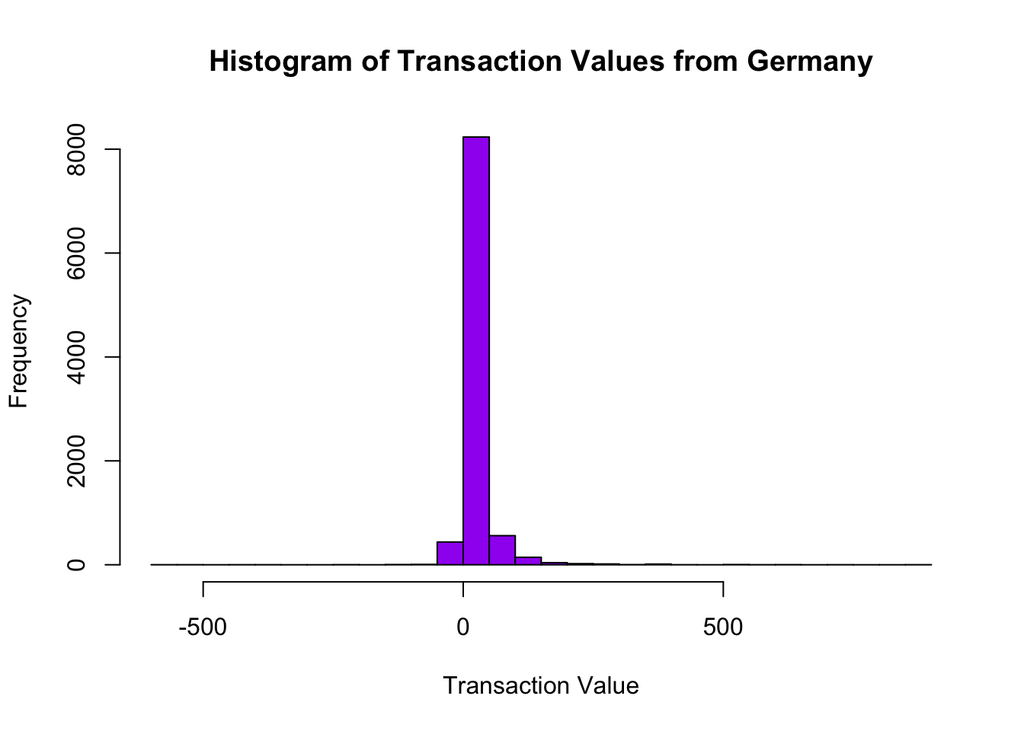

```r
# Use the hist() function to plot
germany_data <- Online_Retail %>% filter(Country == "Germany")

# Create the TransactionValue variable if not already done
germany_data$TransactionValue <- germany_data$Quantity * germany_data$UnitPrice

# Plot the histogram of transaction values
hist(germany_data$TransactionValue,
     main = "Histogram of Transaction Values from Germany",
     xlab = "Transaction Value",
     col = "purple",
     breaks = 50)
```

# Step6: Which customer had the highest number of transactions? Which customer is most valuable (i.e. highest total sum of transactions)

```r
# # Group by CustomerID and count transactions
customer_transactions <- Online_Retail %>%
  group_by(CustomerID) %>%
  summarise(transaction_count = n(),
            total_value = sum(Quantity * UnitPrice, na.rm = TRUE)) %>%
  arrange(desc(transaction_count), desc(total_value))

# Customer with the highest number of transactions
most_transactions_customer <- customer_transactions[which.max(customer_transactions$transaction_count), ]

# Customer who spent the most (most valuable)
most_valuable_customer <- customer_transactions[which.max(customer_transactions$total_value), ]

# Print the results
print(most_transactions_customer)
```

```
## # A tibble: 1 × 3
##   CustomerID transaction_count total_value
##        <dbl>             <int>       <dbl>
## 1         NA            135080    1447682.
```

```r
print(most_valuable_customer)
```

```
## # A tibble: 1 × 3
##   CustomerID transaction_count total_value
##        <dbl>             <int>       <dbl>
## 1         NA            135080    1447682.
```

# Step7: Calculate the percentage of missing values for each variable in the dataset

```r
# Calculate the percentage of missing values
missing_percentage <- colMeans(is.na(Online_Retail)) * 100

# Print missing percentages
print(missing_percentage)
```

```
##         InvoiceNo         StockCode       Description          Quantity
##         0.0000000         0.0000000         0.2683107         0.0000000
##       InvoiceDate         UnitPrice        CustomerID           Country
##         0.0000000         0.0000000        24.9266943         0.0000000
##  TransactionValue  New_Invoice_Date  Invoice_Day_Week  New_Invoice_Hour
##         0.0000000         0.0000000         0.0000000         0.0000000
## New_Invoice_Month
##         0.0000000
```

The percentage of missing values for each variable in the Online_Retail dataset. First, it uses the is.na() function to check each value in the dataset and identify which ones are missing, the colMeans() function finds the average of each column in this matrix.

It tells us how many values are missing compared to the total number of values.

Multiplying by 100, we get the percentage of missing values for each variable.

Finally print missing percentage.

# Step8: What are the number of transactions with missing CustomerID records by countries?

```r
# Filter transactions with missing CustomerID
missing_customer_data <- Online_Retail %>% filter(is.na(CustomerID))

# Count missing CustomerID transactions by country
missing_transactions_by_country <- missing_customer_data %>%
  group_by(Country) %>%
  summarise(missing_count = n())

# Print the result
print(missing_transactions_by_country)
```

```
## # A tibble: 9 × 2
##   Country        missing_count
##   <chr>                  <int>
## 1 Bahrain                    2
## 2 EIRE                     711
## 3 France                    66
## 4 Hong Kong                288
## 5 Israel                    47
## 6 Portugal                  39
## 7 Switzerland              125
## 8 United Kingdom        133600
## 9 Unspecified              202
```

The filter function to create a new dataset, missing_customer_data, that includes only the transactions where the CustomerID is missing.Employs the group_by() function to organize this filtered data by the Country variable it based on different countries. Finally the results are printed, providing how many transactions are missing CustomerID records in each country.

# Step9: On average, how often the costumers comeback to the website for their next shopping

To calculate the average number of days between consecutive transactions

```r
# Convert InvoiceDate to Date type if not already done
Online_Retail$InvoiceDate <- as.Date(Online_Retail$InvoiceDate, format='%m/%d/%Y %H:%M')

# Calculate the difference in days between consecutive shopping transactions
customer_shopping_diff <- Online_Retail %>%
  group_by(CustomerID) %>%
  arrange(CustomerID, InvoiceDate) %>%
  summarise(avg_days_between_shopping = mean(diff(InvoiceDate), na.rm = TRUE))

# Print the result
print(customer_shopping_diff)
```

```
## # A tibble: 4,373 × 2
##    CustomerID avg_days_between_shopping
##         <dbl> <drtn>
##  1      12346 0.000000 days
##  2      12347 2.016575 days
##  3      12348 9.433333 days
##  4      12349 0.000000 days
##  5      12350 0.000000 days
##  6      12352 2.765957 days
##  7      12353 0.000000 days
##  8      12354 0.000000 days
##  9      12355 0.000000 days
## 10      12356 5.224138 days
## # ℹ 4,363 more rows
```

InvoiceDate is in the correct date format using as.Date(), which allows work with the dates properly. CustomerID it can analyze each customer’s shopping history separately The summarise() function then calculates the average time between each customer’s purchases by using the diff() function, Finally, the average number of days between transactions for each customer is printed, giving insight into how frequently customers return to shop on the website.

# Step10: What is the return rate for the French customers?

```r
# Subset data for French customers
french_data <- Online_Retail %>% filter(Country == "France")

# Identify cancelled transactions (negative quantity)
cancelled_transactions <- nrow(french_data %>% filter(Quantity < 0))

# Total number of transactions for France
total_transactions <- nrow(french_data)

# Calculate the return rate
return_rate <- (cancelled_transactions / total_transactions) * 100

# Print the result
print(return_rate)
```

```
## [1] 1.741264
```

Create a new subset called french_data, which contains only the transactions made by customers in France. The code counts these cancelled transactions using nrow(), which gives the total number of rows. It calculates the total number of transactions for French customers by counting the rows in french_data. The return rate is then calculated by dividing the number of cancelled transactions by the total number of transactions and multiplying the result by 100 to express it as a percentage.

# Step11: What is the product that has generated the highest revenue for the retailer?

```r
# Group by StockCode and calculate the total transaction value for each product
product_revenue <- Online_Retail %>%
  group_by(StockCode, Description) %>%
  summarise(total_revenue = sum(Quantity * UnitPrice, na.rm = TRUE), .groups = 'drop') %>%
  arrange(desc(total_revenue))

# Print the product with the highest revenue
highest_revenue_product <- product_revenue[1, ]
print(highest_revenue_product)
```

```
## # A tibble: 1 × 3
##   StockCode Description    total_revenue
##   <chr>     <chr>                  <dbl>
## 1 DOT       DOTCOM POSTAGE       206245.
```

The total revenue for each product by multiplying the quantity sold (Quantity) by the price per unit (UnitPrice). The sum() function adds up all the revenue from each product, and the na.rm = TRUE The total revenue for each product, the results are arranged in descending order using arrange(desc(total_revenue))

# Step12: How many unique customers are represented in the dataset?

```r
# Find the number of unique customers
unique_customers <- length(unique(Online_Retail$CustomerID))

# Print the result
print(unique_customers)
```

```
## [1] 4373
```

The unique() function on the CustomerID column, which extracts all the distinct customer IDs from the dataset. The code prints the total number of unique customers.